# Analyse de survie

Axel Bellec

2/2/2017

**TODO** - Faire le tableau mais à des dates particulières par exemple tous les 6 mois, ou sinon en fonction des probas (pas de 0.1 en 0.1 par exemple). + calculer le complémentaire de `survival`

Tableau de résultat: Passer à la semaine ou au mois

- Construire la courbe de survie.
- intervalles de confiances pour le global

Taux d’évênement au cours du temps  
Bivarié: test du log-rank  
Multivarié: modèle de Cox

# 1 Modélisation longitudinale par des méthodes d’analyse de survie

## 1.1 Définition de la variable arrêt/censure et du délai correspondant

Notre objectif est ici d’étudier la survenue d’évènements au cours du temps. Cela implique d’estimer la probabilité de survenue d’un évènement au cours du temps et également évaluer l’impact d’un facteur sur la survenue de cet évènement.

Afin de mettre en place une modélisation longitudinale par des méthodes d’analyse de survie, nous construisons notre jeu de données.

```r
load(file = "base_vih_df_cleaned.Rdata")

library(dplyr)
df <- base_vih_df %>%
  mutate(duree=as.numeric(d_point-d_debtrt)) %>%
  select(duree, arret_trt, typetrt) %>%
  arrange(duree)
```

On charge notre jeu de données nettoyé des valeurs manquantes. Puis nous calculons le nombre de jours entre la date de point ($\Rightarrow$ date à laquelle l’étude se termine : fin du recueil des informations) et la date de début du traitement. Enfin, nous effectuons sur ce dataset un tri croissant selon le delta de jours.

```r
# Load survival libraries
library(survival)
library(splines)
```

## 1.2 Méthode de Kaplan-Meier

### 1.2.1 Estimations

Nous estimons la survie selon la méthode de Kaplan-Meier.

```r
fits <- survfit(Surv(df$duree, df$arret_trt)~1)
fits
```

```
## Call: survfit(formula = Surv(df$duree, df$arret_trt) ~ 1)
##
##       n  events  median 0.95LCL 0.95UCL
##     881     274    3058    2866      NA
```

```r
summary(fits)
```

```
## Call: survfit(formula = Surv(df$duree, df$arret_trt) ~ 1)
##
##  time n.risk n.event survival std.err lower 95% CI upper 95% CI
##     5    881       3    0.997 0.00196        0.993        1.000
##     7    878       1    0.995 0.00226        0.991        1.000
##    21    877       3    0.992 0.00299        0.986        0.998
##    25    874       1    0.991 0.00320        0.985        0.997
##    31    873       1    0.990 0.00339        0.983        0.996
##    32    872       2    0.988 0.00374        0.980        0.995
##    33    870       1    0.986 0.00391        0.979        0.994
##    40    868       1    0.985 0.00406        0.977        0.993
##    42    866       1    0.984 0.00421        0.976        0.992
##    56    865       1    0.983 0.00436        0.974        0.992
##    61    864       2    0.981 0.00464        0.972        0.990
##    62    862       1    0.980 0.00477        0.970        0.989
```

[output cut: 234 more lines]

### 1.2.2 Représentation de la courbe de survie Kaplan-Meier

```r
library(survminer)
```

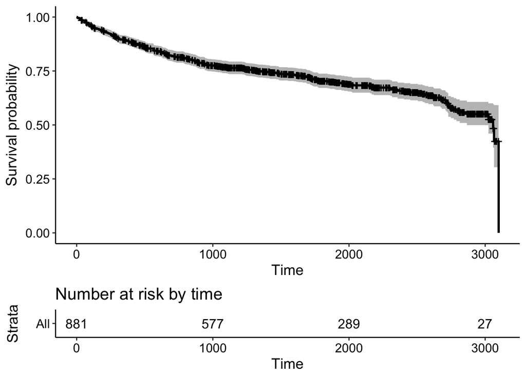

```r
ggsurvplot(fits, risk.table = TRUE)
```

### 1.2.3 Représentation par type de traitement

```r
fits_trt <- survfit(Surv(df$duree, df$arret_trt)~df$typetrt)
fits_trt
```

```
## Call: survfit(formula = Surv(df$duree, df$arret_trt) ~ df$typetrt)
##
##                n events median 0.95LCL 0.95UCL
## df$typetrt=0 304    112   2729    2623      NA
## df$typetrt=1 303    120   2769    1992      NA
## df$typetrt=2 274     42   3099    3058      NA
```

```r
summary(fits_trt)
```

```
## Call: survfit(formula = Surv(df$duree, df$arret_trt) ~ df$typetrt)
##
##                 df$typetrt=0
##  time n.risk n.event survival std.err lower 95% CI upper 95% CI
##     5    304       1    0.997 0.00328        0.990        1.000
##     7    303       1    0.993 0.00464        0.984        1.000
##    21    302       3    0.984 0.00729        0.969        0.998
##    25    299       1    0.980 0.00798        0.965        0.996
##    31    298       1    0.977 0.00860        0.960        0.994
##    33    297       1    0.974 0.00918        0.956        0.992
##    40    296       1    0.970 0.00972        0.952        0.990
##    62    294       1    0.967 0.01023        0.947        0.987
##    66    293       1    0.964 0.01072        0.943        0.985
##    67    292       1    0.960 0.01118        0.939        0.983
##    75    290       1    0.957 0.01162        0.935        0.980
```

[output cut: 253 more lines]

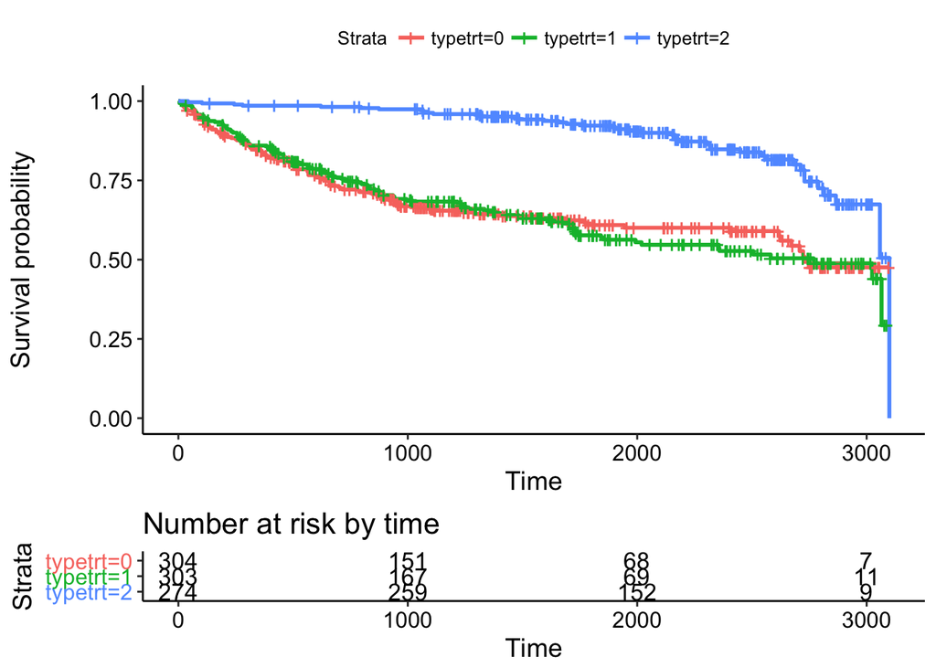

```r
ggsurvplot(fits_trt, risk.table = TRUE)
```